# Magdalena Bay Report

Author

Julian Hemba

# Magdalena Bay

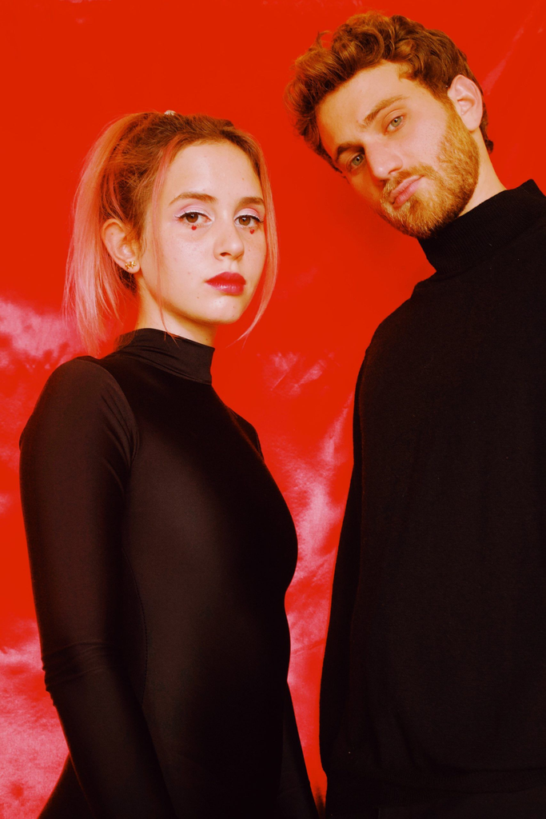

Magdalena Bay

## Background

Magdalena Bay is a duo from Miami, Florida whose singer-songwriters are Mica Tenenbaum and Matthew Lewin. The project was formed in 2016 and is known for its distinct psychedelic pop sound.

Their influences include artists such as Grimes, Charli XCX, and Fiona Apple.

## Quote

“You don’t have to do that. You don’t have to do anything” — Matthew Lewin

## Task

I will be comparing various features from two of my favorite albums. My goal is to uncover patterns within these two albums such as happiness, positivity, and danceability to better understand which contexts they are more appropriate to listen to according to the data.

## Two Albums Included

- A Little Rhythm and a Wicked Feeling (2020)
- Mercurial World (2021)

## Popular Song

[video not shown]

## Importing Data

```r
df <- read.csv("music-analysis Magdalena Bay.csv")
class(df)
```

```
[1] "data.frame"
```

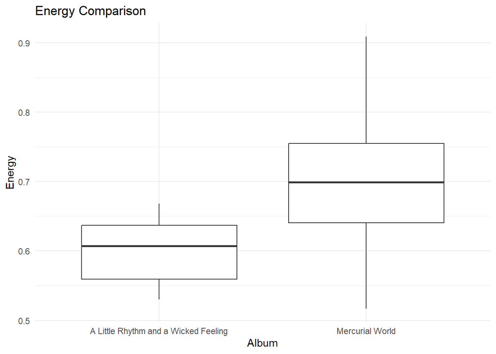

```r
library(dplyr)
library(ggplot2)

# Sorting albums based on song names
df <- df |>
  mutate(
    Album = case_when(
      Song %in% c("How to Get Physical", "Story", "Good Intentions", "Airplane", "Venice", "Killshot", "Stop & Go", "Oh Hell") ~ "A Little Rhythm and a Wicked Feeling",
      Song %in% c("The End", "Mercurial World", "Dawning of the Season", "Secrets (Your Fire)", "You Lose!", "Something for 2", "Chaeri", "Halfway", "Hysterical Us", "Prophecy", "Follow The Leader", "Domino", "Dreamcatching", "The Beginning") ~ "Mercurial World",
      TRUE ~ NA_character_
    )
  )

# Removing duplicates
df <- df |> distinct(Song, .keep_all = TRUE)

# Boxplot comparing albums
ggplot(df, aes(x = Album, y = Energy)) +
  geom_boxplot() +
  labs(
    title = "Energy Comparison",
    x = "Album",
    y = "Energy"
  ) +
  theme_minimal()
```

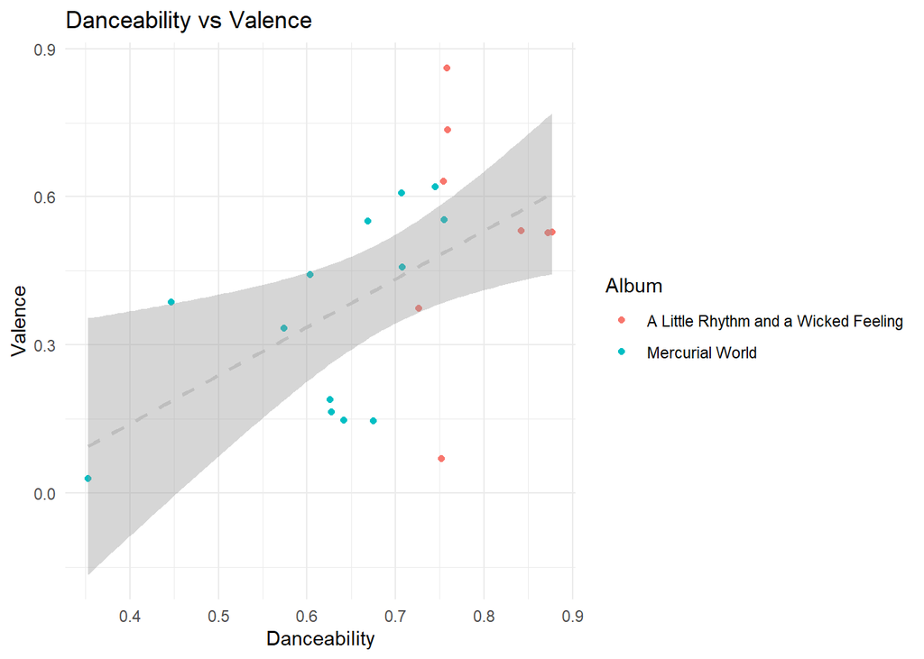

```r
ggplot(df, aes(x = Danceability, y = Valence)) +
  geom_point(aes(color = Album)) +
  geom_smooth(method = "lm", se = TRUE, color = "gray", linetype = "dashed") +
  labs(
    title = "Danceability vs Valence",
    x = "Danceability",
    y = "Valence",
    color = "Album"
  ) +
  theme_minimal()
```

## Histogram Danceability

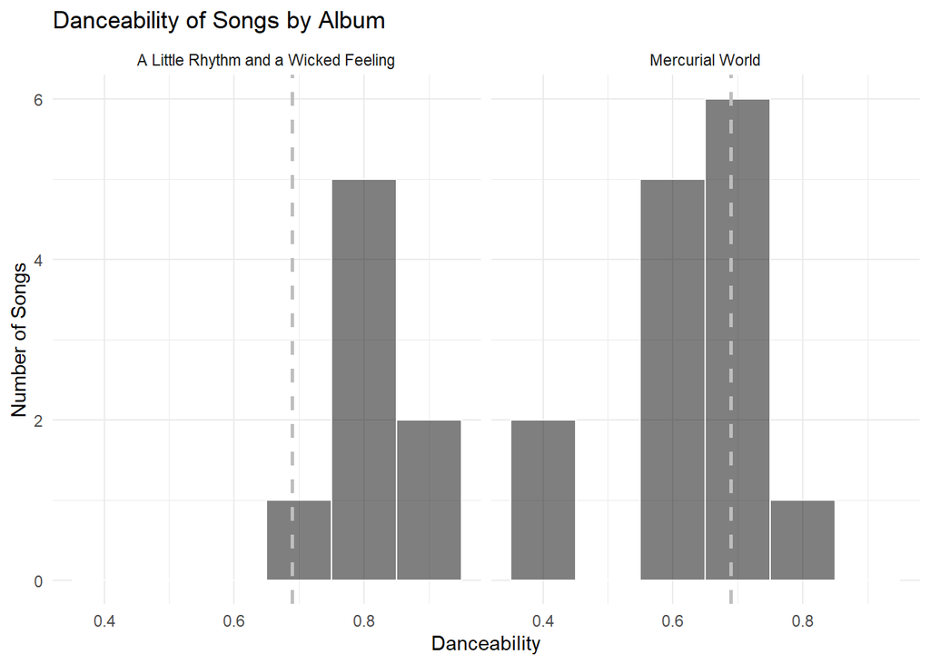

```r
ggplot(df, aes(x = Danceability)) +
  geom_histogram(binwidth = 0.10, fill = "black", color = "white", alpha = 0.5) +
  geom_vline(aes(xintercept = mean(Danceability)),
             color = "gray", linetype = "dashed", linewidth = 1) +
  facet_wrap(~ Album) +
  labs(
    title = "Danceability of Songs by Album",
    x = "Danceability",
    y = "Number of Songs"
  ) +
  theme_minimal()
```

## Danceability Comparison

```r
df %>%
  group_by(Album) %>%
  summarise(Avg_Danceability = mean(Danceability, na.rm = TRUE)) %>%
  arrange(desc(Avg_Danceability))
```

```
# A tibble: 2 × 2
  Album                                Avg_Danceability
  <chr>                                           <dbl>
1 A Little Rhythm and a Wicked Feeling            0.792
2 Mercurial World                                 0.630
```

## Histogram Acousticness

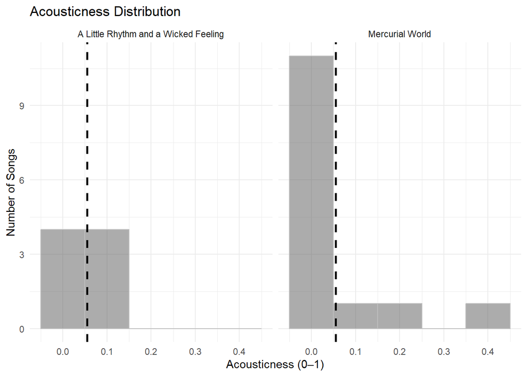

```r
ggplot(df, aes(x = Acousticness)) +
  geom_histogram(binwidth = 0.10, color = "gray", alpha = 0.5) +
  geom_vline(aes(xintercept = mean(Acousticness)),
             linetype = "dashed", linewidth = 1) +
  facet_wrap(~ Album) +
  labs(
    title = "Acousticness Distribution",
    x = "Acousticness (0–1)",
    y = "Number of Songs"
  ) +
  theme_minimal()
```

## Histogram Instrumentalness

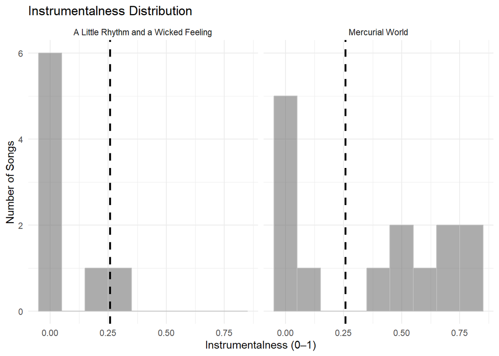

```r
ggplot(df, aes(x = Instrumentalness)) +
  geom_histogram(binwidth = 0.10, color = "gray", alpha = 0.5) +
  geom_vline(aes(xintercept = mean(Instrumentalness)),
             linetype = "dashed", linewidth = 1) +
  facet_wrap(~ Album) +
  labs(
    title = "Instrumentalness Distribution",
    x = "Instrumentalness (0–1)",
    y = "Number of Songs"
  ) +
  theme_minimal()
```

## Instrumentalness Comparison

```r
df %>%
  group_by(Album) %>%
  summarise(Avg_Instrumentalness = mean(Instrumentalness, na.rm = TRUE)) %>%
  arrange(desc(Avg_Instrumentalness))
```

```
# A tibble: 2 × 2
  Album                                Avg_Instrumentalness
  <chr>                                               <dbl>
1 Mercurial World                                    0.370
2 A Little Rhythm and a Wicked Feeling               0.0623
```

## My Favorite Song

[video not shown]

## Scatterplot

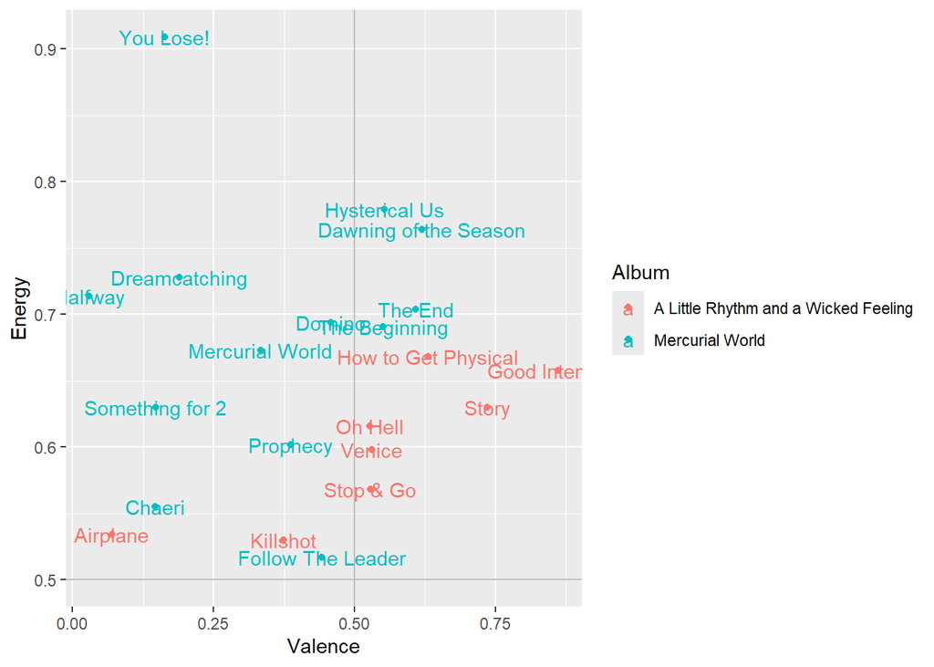

```r
ggplot(df, aes(x = Valence, y = Energy, color = Album)) +
  geom_point() +
  geom_hline(yintercept = 0.5, color = "grey") +
  geom_vline(xintercept = 0.5, color = "grey") +
  geom_text(aes(label = Song))
```

## Happiest Songs

```r
df |> slice_max(Energy, n=3) |> dplyr::select(Song, Energy) |> knitr::kable(digits = 2)
```

| Song | Energy |
| --- | --- |
| You Lose! | 0.91 |
| Secrets (Your Fire) | 0.83 |
| Hysterical Us | 0.78 |

## Most Positive Songs

```r
df |> slice_max(Valence, n=3) |> dplyr::select(Song, Valence) |> knitr::kable(digits = 2)
```

| Song | Valence |
| --- | --- |
| Good Intentions | 0.86 |
| Story | 0.74 |
| How to Get Physical | 0.63 |

## Conclusion

Overall, the data present a striking and sometimes confusing contrast between the two albums. While Mercurial World has songs with much higher energy, they are on average less danceable and positive (lower average valence) than A Little Rhythm and a Wicked Feeling. I found these results to be somewhat at odds with each other, though my best guess to explain this is that Mercurial World is considerably more instrumental, as this may lead it to have more energy. Personally, while A Little Rhythm and a Wicked Feeling is more danceable according to the data, I still prefer dancing to Mercurial World, and I think its a catchier album.